# Identifying robust gene pairs for a single condition

Huiwen Zheng

2023-02-09

**Current package version: v0.0.9**

Coexpression networks are important for revealing functional relationships and interactions between genes. With the application of single-cell RNA-seq, it is now possible to investigate the network in a single cell type.

Here I demonstrate the application of **scRoGG** using the example data stored in the package (memory CD4+ T cells from a healthy human PBMC).

### `scRoGG`

```r
memoryT <- readRDS(system.file("data", "memoryT.rds", package = "scRoGG")) # 472 cells with 13714 genes
memoryT_cor <- scRoGG(memoryT, normalised = T) # true normalised =T if your input data is unnormalised.
```

```
## Removing 12 mitochondrial genes
```

```
## 117143 gene pairs pass the bivariate distribution probability test
```

```
## Using 86 essential genes to estimate proportional distribution
```

```r
# about 10 minutes
```

It will return you a list of three component:

1. `bi_zero`: a vector for the sparsity in a given gene pair.
2. `prop_distribution`: a dataframe contains the correlation distribution for each gene pair.
3. `transformed_data`(optional): a transformed dataframe mainly for visualising the coexpression in a given gene pair. See more in `plotCoExp`.

Next, scRoGG performs an asymptotic test for the coefficient of variation on the correlation distribution against the null distribution. For the likelihood-ratio test, only the upper tail (more strength) gene pairs would be return.

### `robustness`

```r
memoryT_cor_sig <- robustness(memoryT_cor)

# to reduce the computational burden, you can still skip the test and focus on the top 0.1% quantile gene pairs (by set stats=F).

#memoryT_cor_sig 1 <- robustness(memoryT_cor,stats = F)
# about 5 minutes
```

A dataframe will be returned that contains 4 columns, which are:

- gene1, gene2: gene symbols for the gene pair.
- RS: robustness score that incorporates the sign calculated from Pearson correlation method.
- p.adj: adjusted p-values from the asymptotic test that adjusted by BH method.

You may explore the top-ranked gene pairs through literature. One way to plot them is to use our in-built function.

### `plotCoExp`

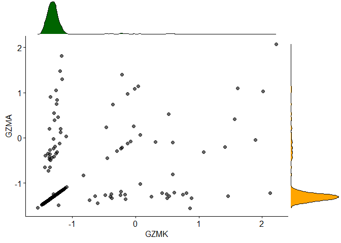

```r
plotCoExp(memoryT_cor$transformed_data,'GZMK','GZMA')
```

Here scRoGG introduces an alternative way to construct coexpression networks.The input data requires an edgelist dataframe (gene1, gene2, value), which can be generated by any methods

### `coExp_network`

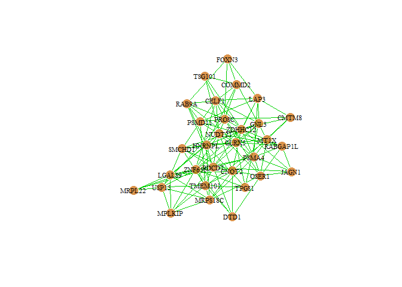

```r
# Here I only plot the first largest sub-communities
# We used Leiden clustering method, for more information, please refer to our manuscript.
memoryT_net <- coExp_network(memoryT_cor_sig[,1:3],n_networks = 1)
```

A list of [*`igraph`*](https://igraph.org/) objects will be returned.

- ‘all’: the full network based on all significant gene pairs.
- ‘sub_1’: the first largest sub-communities.

In addition, scRoGG also implements network-based gene-set enrichment analysis (net-GSEA). This method can be applied to any igraph objects, not limited to scRoGG. Geneset information uses the syntax from [msigdbr](https://cran.r-project.org/web/packages/msigdbr/vignettes/msigdbr-intro.html) package.

### `net_gsea`

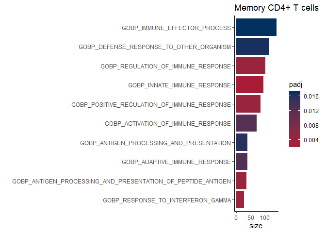